# Dərs 6: Xətti Bərabərləşdirmə (Linear Equating) Metodları

Təhsildə Test Nəticələrinin Bərabərləşdirilməsi - R Proqram Dili ilə

Test Bərabərləşdirmə Kursu

2025-07-15

# 1 Xətti Bərabərləşdirmə (Linear Equating) Metodları

## 1.1 Dərsin Məqsədləri

Bu dərsin sonunda siz:

✅ Xətti bərabərləşdirmənin nəzəri əsaslarını anlayacaqsınız  
✅ Mean equating və linear equating arasında fərqi bilacəksiniz  
✅ R-də Xətti bərabərləşdirmə tətbiq edə biləcəksiniz  
✅ Percentile rank equating metodunu öyrənəcəksiniz  
✅ Real test məlumatları ilə Xətti metodları müqayisə edəcəksiniz

## 1.2 Xətti Bərabərləşdirmənin Nəzəri Əsasları

### 1.2.1 Xətti Bərabərləşdirmə Nədir və Niyə Vacibdir?

**Əsas düstur:**

```
Y = A + BX
```

Burada: - Y = çevrilmiş bal (target test) - X = orijinal bal (source test)  
- A = sabit (intercept) - B = əmsal (slope)

### 1.2.2 Mean vs Linear Equating Fərqləri

Mean və Linear Equating Metodlarının Müqayisəsi

| Xüsusiyyət | Mean.Equating | Linear.Equating |
| --- | --- | --- |
| Məqsəd | Yalnız orta dəyərləri bərabərləşdir | Orta və SD-ni bərabərləşdir |
| Paylanma Forması | Dəyişmir | Bir qədər dəyişir |
| Mərkəzi Tendensiya | Tam uyğunlaşır ⭐⭐⭐ | Tam uyğunlaşır ⭐⭐⭐ |
| Dəyişkənlik | Saxlanılır | Tam uyğunlaşır ⭐⭐⭐ |
| Ekstrem Ballar | Çox dəqiq olmaya bilər | Daha yaxşı ⭐⭐ |
| Hesablama | Sadə ⭐⭐⭐ | Orta mürəkkəb ⭐⭐ |

## 1.3 R Mühitinin Hazırlanması

### 1.3.1 Paketlərin Yüklənməsi

```r
# Paketləri aktivləşdirin
suppressMessages({
  library(equate)      # Test bərabərləşdirmə metodları
  library(psych)       # Psixometrik analizlər
  library(ggplot2)     # Qrafik vizuallaşdırma
  library(dplyr)       # Məlumat manipulyasiyası
  library(knitr)       # Cədvəl formatlaşdırması
  library(gridExtra)   # Qrafik təşkili
})

# Qrafik təması
theme_set(theme_minimal(base_size = 12))
colors_custom <- c("#3498db", "#e74c3c", "#2ecc71", "#f39c12", "#9b59b6")

cat("✅ R mühiti uğurla konfiqurasiya edildi!\n")
```

```
## ✅ R mühiti uğurla konfiqurasiya edildi!
```

### 1.3.2 Xətti Equating Funksiyaları

```r
# Mean equating funksiyası
mean_equating <- function(x_scores, y_scores) {
  mean_x <- mean(x_scores)
  mean_y <- mean(y_scores)

  return(list(
    adjustment = mean_y - mean_x,
    mean_x = mean_x,
    mean_y = mean_y,
    method = "Mean"
  ))
}

# Linear equating funksiyası (Mean + SD)
linear_equating <- function(x_scores, y_scores) {
  mean_x <- mean(x_scores)
  mean_y <- mean(y_scores)
  sd_x <- sd(x_scores)
  sd_y <- sd(y_scores)

  slope <- sd_y / sd_x
  intercept <- mean_y - slope * mean_x

  return(list(
    slope = slope,
    intercept = intercept,
    mean_x = mean_x,
    mean_y = mean_y,
    sd_x = sd_x,
    sd_y = sd_y,
    method = "Linear"
  ))
}

# Percentile rank equating funksiyası
percentile_rank_equating <- function(x_scores, y_scores) {
  # Percentile rank hesablama
  pr_x <- rank(x_scores) / length(x_scores)
  pr_y <- rank(y_scores) / length(y_scores)

  # Orta percentile rank
  mean_pr_x <- mean(pr_x)
  mean_pr_y <- mean(pr_y)

  return(list(
    pr_x = pr_x,
    pr_y = pr_y,
    mean_pr_x = mean_pr_x,
    mean_pr_y = mean_pr_y,
    adjustment = mean_pr_y - mean_pr_x,
    method = "Percentile_Rank"
  ))
}

# Sürətli statistika funksiyası
quick_stats <- function(scores, name = "Test") {
  list(
    name = name,
    n = length(scores),
    mean = round(mean(scores), 2),
    sd = round(sd(scores), 2),
    min = min(scores),
    max = max(scores),
    skewness = round(psych::skew(scores), 3),
    kurtosis = round(psych::kurtosi(scores), 3)
  )
}

cat("✅ Xətti equating funksiyaları hazırlandı!\n")
```

```
## ✅ Xətti equating funksiyaları hazırlandı!
```

# 2 Mean Equating Metodu

## 2.1 Metodun Əsasları

Mean equating ən sadə equating metodudur. Bu metod yalnız iki testin orta dəyərlərini bərabərləşdirir və bütün bərabərləşdirmə sabit bir rəqəmin əlavə edilməsi və ya çıxarılması ilə həyata keçirilir.

**Düstur:**

```
Y = X + (μ_Y - μ_X)
```

### 2.1.1 R-də Tətbiq

```r
# Nümunə məlumatların yaradılması
set.seed(123)
n <- 1200

# Test X nəticələri (Form A - Yazılı İmtahan)
test_x <- rnorm(n, mean = 72, sd = 12)
test_x <- pmax(0, pmin(100, test_x))

# Test Y nəticələri (Form B - Şifahi İmtahan, fərqli parametrlərlə)
test_y <- rnorm(n, mean = 78, sd = 15)
test_y <- pmax(0, pmin(100, test_y))

# Məlumatları data frame-ə yerləşdir
data <- data.frame(
  test_x = test_x,
  test_y = test_y
)

# Əsas statistikalar
cat("=== Test Formalarının Əsas Statistikaları ===\n")
```

```
## === Test Formalarının Əsas Statistikaları ===
```

```r
stats_x <- quick_stats(data$test_x, "Test X (Yazılı)")
stats_y <- quick_stats(data$test_y, "Test Y (Şifahi)")

stats_summary <- data.frame(
  Test = c("X (Yazılı)", "Y (Şifahi)"),
  N = c(stats_x$n, stats_y$n),
  Mean = c(stats_x$mean, stats_y$mean),
  SD = c(stats_x$sd, stats_y$sd),
  Min = c(stats_x$min, stats_y$min),
  Max = c(stats_x$max, stats_y$max),
  Skewness = c(stats_x$skewness, stats_y$skewness),
  Kurtosis = c(stats_x$kurtosis, stats_y$kurtosis)
)

kable(stats_summary,
      caption = "Test Formalarının Təsviri Statistikaları",
      align = "c")
```

Test Formalarının Təsviri Statistikaları

| Test | N | Mean | SD | Min | Max | Skewness | Kurtosis |
| --- | --- | --- | --- | --- | --- | --- | --- |
| X (Yazılı) | 1200 | 72.21 | 11.83 | 38.28270 | 100 | 0.038 | -0.192 |
| Y (Şifahi) | 1200 | 77.68 | 13.99 | 32.28209 | 100 | -0.341 | -0.414 |

```r
# Mean equating tətbiqi
eq_mean <- mean_equating(data$test_x, data$test_y)

cat("\n=== Mean Equating Parametrləri ===\n")
```

```
##
## === Mean Equating Parametrləri ===
```

```r
cat("Test X ortalaması:", round(eq_mean$mean_x, 2), "\n")
```

```
## Test X ortalaması: 72.21
```

```r
cat("Test Y ortalaması:", round(eq_mean$mean_y, 2), "\n")
```

```
## Test Y ortalaması: 77.68
```

```r
cat("Düzəliş (Adjustment):", round(eq_mean$adjustment, 2), "\n")
```

```
## Düzəliş (Adjustment): 5.47
```

### 2.1.2 Mean Equating Transformasiyası

```r
# Mean equating transformasiya funksiyası
equate_score_mean <- function(x) {
  return(x + eq_mean$adjustment)
}

# Test X nəticələrinin Test Y-yə çevrilməsi
equated_scores_mean <- equate_score_mean(data$test_x)

# Nəticələrin müqayisəsi
results_mean <- data.frame(
  Original_X = data$test_x[1:10],
  Equated_to_Y = round(equated_scores_mean[1:10], 1),
  Target_Y = data$test_y[1:10],
  Difference = round(equated_scores_mean[1:10] - data$test_y[1:10], 1)
)

cat("=== Nümunə Mean Equating Transformasiyaları (İlk 10 şagird) ===\n")
```

```
## === Nümunə Mean Equating Transformasiyaları (İlk 10 şagird) ===
```

```r
kable(results_mean,
      caption = "Mean Equating Metodunun Nümunə Nəticələri",
      align = "c")
```

Mean Equating Metodunun Nümunə Nəticələri

| Original_X | Equated_to_Y | Target_Y | Difference |
| --- | --- | --- | --- |
| 65.27429 | 70.7 | 87.29775 | -16.6 |
| 69.23787 | 74.7 | 66.63735 | 8.1 |
| 90.70450 | 96.2 | 90.77287 | 5.4 |
| 72.84610 | 78.3 | 66.78105 | 11.5 |
| 73.55145 | 79.0 | 87.45360 | -8.4 |
| 92.58078 | 98.1 | 94.44992 | 3.6 |
| 77.53099 | 83.0 | 63.17336 | 19.8 |
| 56.81927 | 62.3 | 94.61993 | -32.3 |
| 63.75777 | 69.2 | 70.65701 | -1.4 |
| 66.65206 | 72.1 | 82.41530 | -10.3 |

```r
# Transformasiya keyfiyyətinin yoxlanması
mean_preservation <- abs(mean(equated_scores_mean) - mean(data$test_y))
sd_difference <- abs(sd(equated_scores_mean) - sd(data$test_y))

cat("\n=== Mean Equating Keyfiyyəti ===\n")
```

```
##
## === Mean Equating Keyfiyyəti ===
```

```r
cat("Ortalama qorunması (fərq):", round(mean_preservation, 4), "\n")
```

```
## Ortalama qorunması (fərq): 0
```

```r
cat("SD fərqi (qorunmur):", round(sd_difference, 4), "\n")
```

```
## SD fərqi (qorunmur): 2.1657
```

```r
cat("Equated balların SD-si:", round(sd(equated_scores_mean), 2), "\n")
```

```
## Equated balların SD-si: 11.83
```

```r
cat("Target balların SD-si:", round(sd(data$test_y), 2), "\n")
```

```
## Target balların SD-si: 13.99
```

# 3 Linear Equating Metodu

## 3.1 Metodun Əsasları

**Düstur:**

```
B = σ_Y / σ_X
A = μ_Y - B × μ_X
Y = A + BX
```

### 3.1.1 R-də Linear Equating Tətbiqi

```r
# Linear equating tətbiqi
eq_linear <- linear_equating(data$test_x, data$test_y)

cat("=== Linear Equating Parametrləri ===\n")
```

```
## === Linear Equating Parametrləri ===
```

```r
cat("Slope (B):", round(eq_linear$slope, 4), "\n")
```

```
## Slope (B): 1.1831
```

```r
cat("Intercept (A):", round(eq_linear$intercept, 2), "\n")
```

```
## Intercept (A): -7.75
```

```r
cat("Test X ortalaması:", round(eq_linear$mean_x, 2), "\n")
```

```
## Test X ortalaması: 72.21
```

```r
cat("Test Y ortalaması:", round(eq_linear$mean_y, 2), "\n")
```

```
## Test Y ortalaması: 77.68
```

```r
cat("Test X standart sapması:", round(eq_linear$sd_x, 2), "\n")
```

```
## Test X standart sapması: 11.83
```

```r
cat("Test Y standart sapması:", round(eq_linear$sd_y, 2), "\n")
```

```
## Test Y standart sapması: 13.99
```

```r
# Linear equating transformasiya funksiyası
equate_score_linear <- function(x) {
  return(eq_linear$intercept + eq_linear$slope * x)
}

# Transformasiya
equated_scores_linear <- equate_score_linear(data$test_x)

# Həm orta, həm də SD qorunmasının yoxlanması
mean_preservation_linear <- abs(mean(equated_scores_linear) - mean(data$test_y))
sd_preservation_linear <- abs(sd(equated_scores_linear) - sd(data$test_y))

cat("\n=== Linear Equating Keyfiyyəti ===\n")
```

```
##
## === Linear Equating Keyfiyyəti ===
```

```r
cat("Ortalama qorunması (fərq):", round(mean_preservation_linear, 4), "\n")
```

```
## Ortalama qorunması (fərq): 0
```

```r
cat("SD qorunması (fərq):", round(sd_preservation_linear, 4), "\n")
```

```
## SD qorunması (fərq): 0
```

### 3.1.2 Mean vs Linear Equating Müqayisəsi

```r
# İki metodun nəticələrinin müqayisəsi
comparison_results <- data.frame(
  Original_X = data$test_x[1:15],
  Mean_Equated = round(equated_scores_mean[1:15], 1),
  Linear_Equated = round(equated_scores_linear[1:15], 1),
  Target_Y = data$test_y[1:15],
  Mean_Diff = round(equated_scores_mean[1:15] - data$test_y[1:15], 1),
  Linear_Diff = round(equated_scores_linear[1:15] - data$test_y[1:15], 1),
  Methods_Diff = round(equated_scores_linear[1:15] - equated_scores_mean[1:15], 1)
)

cat("=== Mean vs Linear Equating Nəticələrinin Müqayisəsi ===\n")
```

```
## === Mean vs Linear Equating Nəticələrinin Müqayisəsi ===
```

```r
kable(comparison_results,
      caption = "İki Metodun Transformasiya Nəticələrinin Müqayisəsi",
      align = "c")
```

İki Metodun Transformasiya Nəticələrinin Müqayisəsi

| Original_X | Mean_Equated | Linear_Equated | Target_Y | Mean_Diff | Linear_Diff | Methods_Diff |
| --- | --- | --- | --- | --- | --- | --- |
| 65.27429 | 70.7 | 69.5 | 87.29775 | -16.6 | -17.8 | -1.3 |
| 69.23787 | 74.7 | 74.2 | 66.63735 | 8.1 | 7.5 | -0.5 |
| 90.70450 | 96.2 | 99.6 | 90.77287 | 5.4 | 8.8 | 3.4 |
| 72.84610 | 78.3 | 78.4 | 66.78105 | 11.5 | 11.7 | 0.1 |
| 73.55145 | 79.0 | 79.3 | 87.45360 | -8.4 | -8.2 | 0.2 |
| 92.58078 | 98.1 | 101.8 | 94.44992 | 3.6 | 7.3 | 3.7 |
| 77.53099 | 83.0 | 84.0 | 63.17336 | 19.8 | 20.8 | 1.0 |
| 56.81927 | 62.3 | 59.5 | 94.61993 | -32.3 | -35.1 | -2.8 |
| 63.75777 | 69.2 | 67.7 | 70.65701 | -1.4 | -3.0 | -1.5 |
| 66.65206 | 72.1 | 71.1 | 82.41530 | -10.3 | -11.3 | -1.0 |
| 86.68898 | 92.2 | 94.8 | 81.02756 | 11.1 | 13.8 | 2.7 |
| 76.31777 | 81.8 | 82.5 | 71.59205 | 10.2 | 10.9 | 0.8 |
| 76.80926 | 82.3 | 83.1 | 82.02154 | 0.3 | 1.1 | 0.8 |
| 73.32819 | 78.8 | 79.0 | 59.54354 | 19.3 | 19.5 | 0.2 |
| 65.32991 | 70.8 | 69.5 | 75.95795 | -5.2 | -6.4 | -1.3 |

```r
# Metodlar arasında ən böyük fərqi tapın
max_method_diff <- max(abs(comparison_results$Methods_Diff))
avg_method_diff <- mean(abs(comparison_results$Methods_Diff))

cat("\n=== Metodlar Arasında Fərqlər ===\n")
```

```
##
## === Metodlar Arasında Fərqlər ===
```

```r
cat("Ən böyük fərq:", round(max_method_diff, 2), "bal\n")
```

```
## Ən böyük fərq: 3.7 bal
```

```r
cat("Orta mütləq fərq:", round(avg_method_diff, 2), "bal\n")
```

```
## Orta mütləq fərq: 1.42 bal
```

```r
# Statistik göstəricilər
method_summary <- data.frame(
  Method = c("Mean Equating", "Linear Equating"),
  Mean_Error = c(mean(equated_scores_mean - data$test_y),
                 mean(equated_scores_linear - data$test_y)),
  RMSE = c(sqrt(mean((equated_scores_mean - data$test_y)^2)),
           sqrt(mean((equated_scores_linear - data$test_y)^2))),
  MAE = c(mean(abs(equated_scores_mean - data$test_y)),
          mean(abs(equated_scores_linear - data$test_y))),
  Correlation = c(cor(equated_scores_mean, data$test_y),
                  cor(equated_scores_linear, data$test_y))
)

method_summary[, 2:5] <- round(method_summary[, 2:5], 4)

cat("\n=== Metodların Performans Müqayisəsi ===\n")
```

```
##
## === Metodların Performans Müqayisəsi ===
```

```r
kable(method_summary,
      caption = "Mean və Linear Equating Metodlarının Keyfiyyət Göstəriciləri",
      align = c("l", "c", "c", "c", "c"))
```

Mean və Linear Equating Metodlarının Keyfiyyət Göstəriciləri

| Method | Mean_Error | RMSE | MAE | Correlation |
| --- | --- | --- | --- | --- |
| Mean Equating | 0 | 18.4322 | 14.9752 | -0.0132 |
| Linear Equating | 0 | 19.9102 | 16.1298 | -0.0132 |

# 4 Percentile Rank Equating

## 4.1 Metodun Əsasları

Percentile rank equating hər bir balın öz qrupundakı nisbi mövqeyini (percentile rank) əsas götürür. Bu metod paylanma formasından asılı olmayan bərabərləşdirmə təmin edir.

### 4.1.1 R-də Percentile Rank Equating

```r
# Percentile rank equating tətbiqi
eq_percentile <- percentile_rank_equating(data$test_x, data$test_y)

cat("=== Percentile Rank Equating Nəticələri ===\n")
```

```
## === Percentile Rank Equating Nəticələri ===
```

```r
cat("Test X orta percentile rank:", round(eq_percentile$mean_pr_x, 4), "\n")
```

```
## Test X orta percentile rank: 0.5004
```

```r
cat("Test Y orta percentile rank:", round(eq_percentile$mean_pr_y, 4), "\n")
```

```
## Test Y orta percentile rank: 0.5004
```

```r
cat("Percentile rank düzəlişi:", round(eq_percentile$adjustment, 4), "\n")
```

```
## Percentile rank düzəlişi: 0
```

```r
# Percentile rank transformasiya funksiyası
equate_score_percentile <- function(x_scores, reference_x, reference_y) {
  # X balının percentile rank-ni tap
  pr_x <- rank(c(reference_x, x_scores))[length(reference_x) + 1:length(x_scores)] /
          (length(reference_x) + 1)

  # Bu percentile rank-a uyğun Y balını tap
  sorted_y <- sort(reference_y)
  indices <- round(pr_x * length(reference_y))
  indices <- pmax(1, pmin(length(reference_y), indices))

  return(sorted_y[indices])
}

# Percentile equating tətbiqi (ilk 100 şagird üçün)
sample_indices <- 1:100
equated_scores_percentile <- equate_score_percentile(
  data$test_x[sample_indices],
  data$test_x,
  data$test_y
)

# Nəticələrin müqayisəsi
percentile_results <- data.frame(
  Original_X = data$test_x[sample_indices[1:10]],
  Percentile_Equated = round(equated_scores_percentile[1:10], 1),
  Linear_Equated = round(equated_scores_linear[sample_indices[1:10]], 1),
  Target_Y = data$test_y[sample_indices[1:10]],
  Percentile_Diff = round(equated_scores_percentile[1:10] - data$test_y[sample_indices[1:10]], 1),
  Linear_Diff = round(equated_scores_linear[sample_indices[1:10]] - data$test_y[sample_indices[1:10]], 1)
)

cat("\n=== Percentile Rank vs Linear Equating Müqayisəsi ===\n")
```

```
##
## === Percentile Rank vs Linear Equating Müqayisəsi ===
```

```r
kable(percentile_results,
      caption = "Percentile Rank və Linear Equating Nəticələrinin Müqayisəsi",
      align = "c")
```

Percentile Rank və Linear Equating Nəticələrinin Müqayisəsi

| Original_X | Percentile_Equated | Linear_Equated | Target_Y | Percentile_Diff | Linear_Diff |
| --- | --- | --- | --- | --- | --- |
| 65.27429 | 70.4 | 69.5 | 87.29775 | -16.9 | -17.8 |
| 69.23787 | 75.3 | 74.2 | 66.63735 | 8.7 | 7.5 |
| 90.70450 | 100.0 | 99.6 | 90.77287 | 9.2 | 8.8 |
| 72.84610 | 80.9 | 78.4 | 66.78105 | 14.1 | 11.7 |
| 73.55145 | 81.8 | 79.3 | 87.45360 | -5.6 | -8.2 |
| 92.58078 | 100.0 | 101.8 | 94.44992 | 5.6 | 7.3 |
| 77.53099 | 88.0 | 84.0 | 63.17336 | 24.8 | 20.8 |
| 56.81927 | 59.6 | 59.5 | 94.61993 | -35.0 | -35.1 |
| 63.75777 | 68.2 | 67.7 | 70.65701 | -2.4 | -3.0 |
| 66.65206 | 72.5 | 71.1 | 82.41530 | -9.9 | -11.3 |

# 5 Praktiki Nümunə: Tibb Fakültəsi Qəbul İmtahanı

## 5.1 Məlumatların Yaradılması

```r
# Tibb fakültəsi qəbul imtahanı məlumatları
set.seed(456)
n_students <- 1500

# Fen imtahanı nəticələri (Kimya, Fizika, Biologiya)
science_exam <- rbeta(n_students, 7, 3) * 100  # Sol çarpık paylanma
science_exam <- pmax(20, pmin(100, science_exam))

# Ümumi bacarıqlar imtahanı (daha normal paylanma)
general_exam <- rnorm(n_students, mean = 75, sd = 13)
general_exam <- pmax(0, pmin(100, general_exam))

# Məlumatları data frame-ə yerləşdir
medical_data <- data.frame(
  science = science_exam,
  general = general_exam,
  student_id = 1:n_students
)

# Paylanmaların xüsusiyyətləri
cat("=== Tibb Fakültəsi İmtahanı Statistikaları ===\n")
```

```
## === Tibb Fakültəsi İmtahanı Statistikaları ===
```

```r
science_stats <- quick_stats(medical_data$science, "Fen İmtahanı")
general_stats <- quick_stats(medical_data$general, "Ümumi Bacarıqlar")

medical_summary <- data.frame(
  Test = c("Fen İmtahanı", "Ümumi Bacarıqlar"),
  N = c(science_stats$n, general_stats$n),
  Mean = c(science_stats$mean, general_stats$mean),
  SD = c(science_stats$sd, general_stats$sd),
  Min = c(science_stats$min, general_stats$min),
  Max = c(science_stats$max, general_stats$max),
  Skewness = c(science_stats$skewness, general_stats$skewness),
  Kurtosis = c(science_stats$kurtosis, general_stats$kurtosis)
)

kable(medical_summary,
      caption = "Tibb Fakültəsi İmtahan Statistikaları",
      align = "c")
```

Tibb Fakültəsi İmtahan Statistikaları

| Test | N | Mean | SD | Min | Max | Skewness | Kurtosis |
| --- | --- | --- | --- | --- | --- | --- | --- |
| Fen İmtahanı | 1500 | 69.35 | 14.00 | 25.25602 | 98.35692 | -0.470 | -0.260 |
| Ümumi Bacarıqlar | 1500 | 74.80 | 12.13 | 30.27106 | 100.00000 | -0.101 | -0.209 |

```r
# Korelasiya
correlation_medical <- cor(medical_data$science, medical_data$general)
cat("\nFen və Ümumi Bacarıqlar arasında korelasiya:", round(correlation_medical, 3), "\n")
```

```
##
## Fen və Ümumi Bacarıqlar arasında korelasiya: -0.038
```

## 5.2 Bütün Metodların Tətbiqi

```r
# Bütün metodların tətbiqi (Fen → Ümumi Bacarıqlar)
eq_medical_mean <- mean_equating(medical_data$science, medical_data$general)
eq_medical_linear <- linear_equating(medical_data$science, medical_data$general)

cat("=== Tibb İmtahanı Equating Nəticələri ===\n")
```

```
## === Tibb İmtahanı Equating Nəticələri ===
```

```r
cat("Mean equating düzəlişi:", round(eq_medical_mean$adjustment, 2), "\n")
```

```
## Mean equating düzəlişi: 5.45
```

```r
cat("Linear equating slope:", round(eq_medical_linear$slope, 4), "\n")
```

```
## Linear equating slope: 0.8663
```

```r
cat("Linear equating intercept:", round(eq_medical_linear$intercept, 2), "\n")
```

```
## Linear equating intercept: 14.72
```

```r
# Transformasiya funksiyaları
fen_to_general_mean <- function(x) x + eq_medical_mean$adjustment
fen_to_general_linear <- function(x) eq_medical_linear$intercept + eq_medical_linear$slope * x

# Fen imtahan nəticələrinin ümumi bacarıqlara çevrilməsi
medical_data$fen_to_general_mean <- fen_to_general_mean(medical_data$science)
medical_data$fen_to_general_linear <- fen_to_general_linear(medical_data$science)

# Nəticələrin müqayisəsi
medical_comparison <- data.frame(
  Original_Science = medical_data$science[1:12],
  Original_General = medical_data$general[1:12],
  Mean_Equated = round(medical_data$fen_to_general_mean[1:12], 1),
  Linear_Equated = round(medical_data$fen_to_general_linear[1:12], 1),
  Mean_Diff = round(medical_data$fen_to_general_mean[1:12] - medical_data$general[1:12], 1),
  Linear_Diff = round(medical_data$fen_to_general_linear[1:12] - medical_data$general[1:12], 1)
)

cat("\n=== Tibb İmtahanı Transformasiya Nəticələri ===\n")
```

```
##
## === Tibb İmtahanı Transformasiya Nəticələri ===
```

```r
kable(medical_comparison,
      caption = "Fen İmtahanının Ümumi Bacarıqlara Çevrilməsi",
      align = "c")
```

Fen İmtahanının Ümumi Bacarıqlara Çevrilməsi

| Original_Science | Original_General | Mean_Equated | Linear_Equated | Mean_Diff | Linear_Diff |
| --- | --- | --- | --- | --- | --- |
| 88.15153 | 75.48574 | 93.6 | 91.1 | 18.1 | 15.6 |
| 58.47888 | 65.97639 | 63.9 | 65.4 | -2.1 | -0.6 |
| 54.72710 | 72.86357 | 60.2 | 62.1 | -12.7 | -10.7 |
| 88.61666 | 67.21334 | 94.1 | 91.5 | 26.9 | 24.3 |
| 80.69802 | 81.08144 | 86.1 | 84.6 | 5.1 | 3.5 |
| 75.15876 | 76.63418 | 80.6 | 79.8 | 4.0 | 3.2 |
| 57.05962 | 77.88398 | 62.5 | 64.2 | -15.4 | -13.7 |
| 65.62931 | 94.51694 | 71.1 | 71.6 | -23.4 | -22.9 |
| 50.16236 | 70.19087 | 55.6 | 58.2 | -14.6 | -12.0 |
| 59.46162 | 72.46517 | 64.9 | 66.2 | -7.6 | -6.2 |
| 83.28369 | 100.00000 | 88.7 | 86.9 | -11.3 | -13.1 |
| 43.03948 | 67.05306 | 48.5 | 52.0 | -18.6 | -15.0 |

```r
# Keyfiyyət qiymətləndirilməsi
medical_quality <- data.frame(
  Method = c("Mean Equating", "Linear Equating"),
  RMSE = c(sqrt(mean((medical_data$fen_to_general_mean - medical_data$general)^2)),
           sqrt(mean((medical_data$fen_to_general_linear - medical_data$general)^2))),
  MAE = c(mean(abs(medical_data$fen_to_general_mean - medical_data$general)),
          mean(abs(medical_data$fen_to_general_linear - medical_data$general))),
  Bias = c(mean(medical_data$fen_to_general_mean - medical_data$general),
           mean(medical_data$fen_to_general_linear - medical_data$general)),
  Correlation = c(cor(medical_data$fen_to_general_mean, medical_data$general),
                  cor(medical_data$fen_to_general_linear, medical_data$general))
)

medical_quality[, 2:5] <- round(medical_quality[, 2:5], 4)

cat("\n=== Metodların Performans Müqayisəsi ===\n")
```

```
##
## === Metodların Performans Müqayisəsi ===
```

```r
kable(medical_quality,
      caption = "Tibb İmtahanı Equating Keyfiyyət Göstəriciləri",
      align = c("l", "c", "c", "c", "c"))
```

Tibb İmtahanı Equating Keyfiyyət Göstəriciləri

| Method | RMSE | MAE | Bias | Correlation |
| --- | --- | --- | --- | --- |
| Mean Equating | 18.8669 | 15.2666 | 0 | -0.0384 |
| Linear Equating | 17.4733 | 14.1525 | 0 | -0.0384 |

# 6 Vizual Təqdimat və Analiz

## 6.1 Paylanmaların Vizualizasiyası

[figure not shown]

Test Paylanmalarının və Equating Nəticələrinin Vizualizasiyası

```r
# Paylanmaların və equating nəticələrinin vizualizasiyası
p1 <- ggplot(medical_data, aes(x = science)) +
  geom_histogram(aes(y = ..density..), bins = 30, alpha = 0.7,
                 fill = colors_custom[1], color = "white") +
  geom_density(color = colors_custom[1], size = 1.2) +
  labs(title = "Fen İmtahanı Paylanması",
       subtitle = paste("Skewness:", round(science_stats$skewness, 3)),
       x = "Fen İmtahanı Balları", y = "Sıxlıq") +
  theme_minimal()

p2 <- ggplot(medical_data, aes(x = general)) +
  geom_histogram(aes(y = ..density..), bins = 30, alpha = 0.7,
                 fill = colors_custom[2], color = "white") +
  geom_density(color = colors_custom[2], size = 1.2) +
  labs(title = "Ümumi Bacarıqlar Paylanması",
       subtitle = paste("Skewness:", round(general_stats$skewness, 3)),
       x = "Ümumi Bacarıqlar Balları", y = "Sıxlıq") +
  theme_minimal()

# Equating nəticələrinin paylanması
p3 <- ggplot(medical_data) +
  geom_density(aes(x = fen_to_general_linear), alpha = 0.7,
               fill = colors_custom[3], color = colors_custom[3], size = 1.2) +
  geom_density(aes(x = general), alpha = 0.7,
               fill = colors_custom[4], color = colors_custom[4], size = 1.2) +
  labs(title = "Linear Equating Nəticələri",
       subtitle = "Mavi: Equated Fen, Qırmızı: Original Ümumi",
       x = "Bal", y = "Sıxlıq") +
  theme_minimal()

# Scatter plot
p4 <- ggplot(medical_data, aes(x = science, y = general)) +
  geom_point(alpha = 0.5, color = colors_custom[1]) +
  geom_smooth(method = "lm", color = colors_custom[2], se = FALSE) +
  geom_abline(intercept = eq_medical_linear$intercept,
              slope = eq_medical_linear$slope,
              color = colors_custom[3], size = 1.2, linetype = "dashed") +
  labs(title = "Fen və Ümumi Bacarıqlar Münasibəti",
       subtitle = paste("Korelasiya:", round(correlation_medical, 3)),
       x = "Fen İmtahanı Balları", y = "Ümumi Bacarıqlar Balları") +
  theme_minimal()

# Qrafik göstərimi
grid.arrange(p1, p2, p3, p4, ncol = 2)
```

## 6.2 Residual Analizi

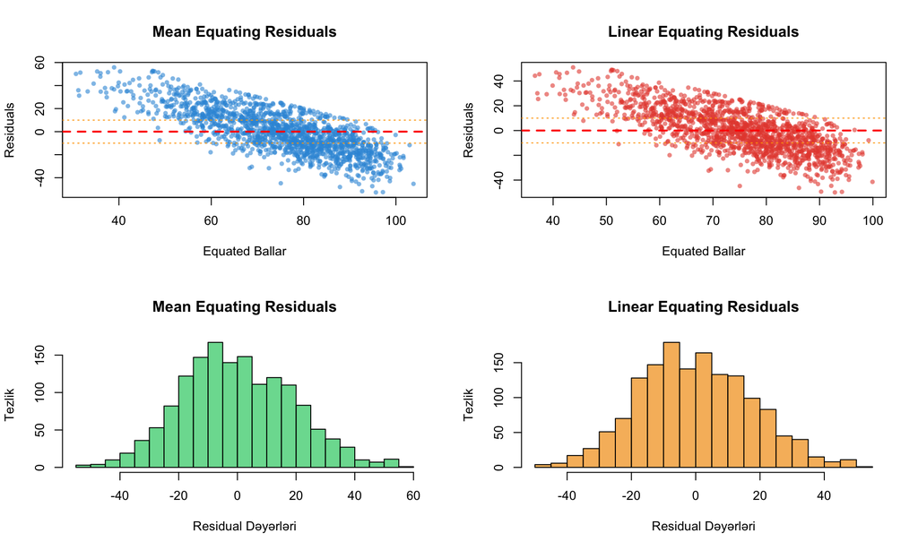

Residual Analizi və Equating Keyfiyyəti

```r
# Residual hesablaması
medical_data$residuals_mean <- medical_data$general - medical_data$fen_to_general_mean
medical_data$residuals_linear <- medical_data$general - medical_data$fen_to_general_linear

# Residual plotları
par(mfrow = c(2, 2))

# Mean equating residuals
plot(medical_data$fen_to_general_mean, medical_data$residuals_mean,
     col = adjustcolor(colors_custom[1], alpha.f = 0.6), pch = 16, cex = 0.8,
     main = "Mean Equating Residuals",
     xlab = "Equated Ballar", ylab = "Residuals")
abline(h = 0, col = "red", lwd = 2, lty = 2)
abline(h = c(-10, 10), col = "orange", lwd = 1, lty = 3)

# Linear equating residuals
plot(medical_data$fen_to_general_linear, medical_data$residuals_linear,
     col = adjustcolor(colors_custom[2], alpha.f = 0.6), pch = 16, cex = 0.8,
     main = "Linear Equating Residuals",
     xlab = "Equated Ballar", ylab = "Residuals")
abline(h = 0, col = "red", lwd = 2, lty = 2)
abline(h = c(-10, 10), col = "orange", lwd = 1, lty = 3)

# Residual histogramları
hist(medical_data$residuals_mean, breaks = 30,
     col = adjustcolor(colors_custom[3], alpha.f = 0.7),
     main = "Mean Equating Residuals",
     xlab = "Residual Dəyərləri", ylab = "Tezlik")

hist(medical_data$residuals_linear, breaks = 30,
     col = adjustcolor(colors_custom[4], alpha.f = 0.7),
     main = "Linear Equating Residuals",
     xlab = "Residual Dəyərləri", ylab = "Tezlik")
```

```r
# Residual statistikaları
cat("=== Residual Analizi Statistikaları ===\n")
```

```
## === Residual Analizi Statistikaları ===
```

```r
residual_stats <- data.frame(
  Method = c("Mean Equating", "Linear Equating"),
  Mean_Residual = c(mean(medical_data$residuals_mean), mean(medical_data$residuals_linear)),
  SD_Residual = c(sd(medical_data$residuals_mean), sd(medical_data$residuals_linear)),
  Min_Residual = c(min(medical_data$residuals_mean), min(medical_data$residuals_linear)),
  Max_Residual = c(max(medical_data$residuals_mean), max(medical_data$residuals_linear)),
  IQR_Residual = c(IQR(medical_data$residuals_mean), IQR(medical_data$residuals_linear))
)

residual_stats[, 2:6] <- round(residual_stats[, 2:6], 3)

kable(residual_stats,
      caption = "Residual Analizi Statistikaları",
      align = c("l", "c", "c", "c", "c", "c"))
```

Residual Analizi Statistikaları

| Method | Mean_Residual | SD_Residual | Min_Residual | Max_Residual | IQR_Residual |
| --- | --- | --- | --- | --- | --- |
| Mean Equating | 0 | 18.873 | -52.726 | 55.770 | 26.701 |
| Linear Equating | 0 | 17.479 | -49.936 | 50.976 | 24.717 |

# 7 Fərqli Bal Aralıqlarında Equating

## 7.1 Bal Aralıqlarına Görə Performans

```r
# Bal aralıqlarına görə equating performansını analiz et
create_score_intervals <- function(scores, n_intervals = 5) {
  quantiles <- quantile(scores, probs = seq(0, 1, length.out = n_intervals + 1))
  intervals <- cut(scores, breaks = quantiles, include.lowest = TRUE, labels = FALSE)
  return(intervals)
}

# Fen imtahanı üçün bal aralıqları
medical_data$score_interval <- create_score_intervals(medical_data$science, 5)

# Hər aralıq üçün equating performansı
interval_performance <- medical_data %>%
  group_by(score_interval) %>%
  summarise(
    n = n(),
    mean_science = mean(science),
    mean_general = mean(general),
    mean_equated_mean = mean(fen_to_general_mean),
    mean_equated_linear = mean(fen_to_general_linear),
    rmse_mean = sqrt(mean((fen_to_general_mean - general)^2)),
    rmse_linear = sqrt(mean((fen_to_general_linear - general)^2)),
    bias_mean = mean(fen_to_general_mean - general),
    bias_linear = mean(fen_to_general_linear - general),
    .groups = 'drop'
  )

# Aralıq etiketlərini əlavə et
interval_performance$interval_label <- paste("Aralıq", interval_performance$score_interval)

cat("=== Bal Aralıqlarına Görə Equating Performansı ===\n")
```

```
## === Bal Aralıqlarına Görə Equating Performansı ===
```

```r
kable(interval_performance %>%
        mutate(across(where(is.numeric), ~ round(.x, 3))) %>%
        select(-score_interval),
      caption = "Müxtəlif Bal Aralıqlarında Equating Keyfiyyəti",
      align = "c")
```

Müxtəlif Bal Aralıqlarında Equating Keyfiyyəti

| n | mean_science | mean_general | mean_equated_mean | mean_equated_linear | rmse_mean | rmse_linear | bias_mean | bias_linear | interval_label |
| --- | --- | --- | --- | --- | --- | --- | --- | --- | --- |
| 300 | 48.153 | 75.679 | 53.600 | 56.435 | 26.076 | 23.418 | -22.079 | -19.243 | Aralıq 1 |
| 300 | 62.354 | 74.441 | 67.801 | 68.737 | 14.913 | 14.453 | -6.640 | -5.704 | Aralıq 2 |
| 300 | 70.893 | 74.808 | 76.340 | 76.134 | 12.482 | 12.391 | 1.532 | 1.326 | Aralıq 3 |
| 300 | 78.081 | 74.347 | 83.527 | 82.360 | 15.365 | 14.651 | 9.181 | 8.014 | Aralıq 4 |
| 300 | 87.282 | 74.723 | 92.729 | 90.331 | 22.035 | 20.027 | 18.006 | 15.608 | Aralıq 5 |

```r
# Hansı aralıqda hansı metodun daha yaxşı olduğunu müəyyən et
better_method_by_interval <- ifelse(interval_performance$rmse_mean < interval_performance$rmse_linear,
                                   "Mean Equating", "Linear Equating")

interval_comparison <- data.frame(
  Interval = interval_performance$interval_label,
  Score_Range = paste(round(interval_performance$mean_science - 5, 0), "-",
                     round(interval_performance$mean_science + 5, 0)),
  Better_Method = better_method_by_interval,
  RMSE_Difference = round(abs(interval_performance$rmse_mean - interval_performance$rmse_linear), 3)
)

cat("\n=== Aralıqlara Görə Daha Yaxşı Metod ===\n")
```

```
##
## === Aralıqlara Görə Daha Yaxşı Metod ===
```

```r
kable(interval_comparison,
      caption = "Hər Bal Aralığında Daha Yaxşı Equating Metodu",
      align = c("l", "c", "c", "c"))
```

Hər Bal Aralığında Daha Yaxşı Equating Metodu

| Interval | Score_Range | Better_Method | RMSE_Difference |
| --- | --- | --- | --- |
| Aralıq 1 | 43 - 53 | Linear Equating | 2.658 |
| Aralıq 2 | 57 - 67 | Linear Equating | 0.460 |
| Aralıq 3 | 66 - 76 | Linear Equating | 0.091 |
| Aralıq 4 | 73 - 83 | Linear Equating | 0.714 |
| Aralıq 5 | 82 - 92 | Linear Equating | 2.009 |

# 8 Bootstrap Güven Aralıqları

## 8.1 Bootstrap Analizi

```r
# Bootstrap analizi funksiyası
bootstrap_linear_equating <- function(data_x, data_y, n_boot = 1000) {
  n <- length(data_x)
  boot_results <- matrix(NA, n_boot, 3)
  colnames(boot_results) <- c("mean_adjustment", "linear_slope", "linear_intercept")

  for (i in 1:n_boot) {
    # Bootstrap nümunəsi
    boot_indices <- sample(1:n, n, replace = TRUE)
    boot_x <- data_x[boot_indices]
    boot_y <- data_y[boot_indices]

    # Mean equating
    mean_eq <- mean_equating(boot_x, boot_y)

    # Linear equating
    linear_eq <- linear_equating(boot_x, boot_y)

    boot_results[i, "mean_adjustment"] <- mean_eq$adjustment
    boot_results[i, "linear_slope"] <- linear_eq$slope
    boot_results[i, "linear_intercept"] <- linear_eq$intercept
  }

  return(boot_results)
}

# Bootstrap analizinin aparılması
cat("=== Bootstrap Analizi Aparılır ===\n")
```

```
## === Bootstrap Analizi Aparılır ===
```

```r
cat("1000 bootstrap nümunəsi yaradılır...\n")
```

```
## 1000 bootstrap nümunəsi yaradılır...
```

```r
boot_results <- bootstrap_linear_equating(medical_data$science, medical_data$general, 1000)

# Bootstrap nəticələrinin statistikası
boot_summary <- data.frame(
  Parameter = c("Mean Adjustment", "Linear Slope", "Linear Intercept"),
  Original = c(eq_medical_mean$adjustment, eq_medical_linear$slope, eq_medical_linear$intercept),
  Boot_Mean = c(mean(boot_results[, "mean_adjustment"]),
                mean(boot_results[, "linear_slope"]),
                mean(boot_results[, "linear_intercept"])),
  Boot_SD = c(sd(boot_results[, "mean_adjustment"]),
              sd(boot_results[, "linear_slope"]),
              sd(boot_results[, "linear_intercept"])),
  CI_2.5 = c(quantile(boot_results[, "mean_adjustment"], 0.025),
             quantile(boot_results[, "linear_slope"], 0.025),
             quantile(boot_results[, "linear_intercept"], 0.025)),
  CI_97.5 = c(quantile(boot_results[, "mean_adjustment"], 0.975),
              quantile(boot_results[, "linear_slope"], 0.975),
              quantile(boot_results[, "linear_intercept"], 0.975))
)

boot_summary[, 2:6] <- round(boot_summary[, 2:6], 4)

cat("\n=== Bootstrap Güven Aralıqları ===\n")
```

```
##
## === Bootstrap Güven Aralıqları ===
```

```r
kable(boot_summary,
      caption = "Bootstrap Güven Aralıqları (95%)",
      align = c("l", "c", "c", "c", "c", "c"))
```

Bootstrap Güven Aralıqları (95%)

| Parameter | Original | Boot_Mean | Boot_SD | CI_2.5 | CI_97.5 |
| --- | --- | --- | --- | --- | --- |
| Mean Adjustment | 5.4469 | 5.4740 | 0.4793 | 4.5274 | 6.4064 |
| Linear Slope | 0.8663 | 0.8660 | 0.0220 | 0.8227 | 0.9087 |
| Linear Intercept | 14.7226 | 14.7633 | 1.6736 | 11.4194 | 17.9168 |

```r
# Bootstrap parametrlərinin sabitliyini yoxlayın
parameter_stability <- data.frame(
  Parameter = c("Mean Adjustment", "Linear Slope", "Linear Intercept"),
  Coefficient_of_Variation = c(sd(boot_results[, "mean_adjustment"]) / abs(mean(boot_results[, "mean_adjustment"])),
                              sd(boot_results[, "linear_slope"]) / mean(boot_results[, "linear_slope"]),
                              sd(boot_results[, "linear_intercept"]) / abs(mean(boot_results[, "linear_intercept"])))
)

parameter_stability[, 2] <- round(parameter_stability[, 2], 4)

cat("\n=== Parametr Sabitlik Göstəriciləri ===\n")
```

```
##
## === Parametr Sabitlik Göstəriciləri ===
```

```r
kable(parameter_stability,
      caption = "Bootstrap Parametrlərinin Dəyişkənlik Əmsalları",
      align = c("l", "c"))
```

Bootstrap Parametrlərinin Dəyişkənlik Əmsalları

| Parameter | Coefficient_of_Variation |
| --- | --- |
| Mean Adjustment | 0.0876 |
| Linear Slope | 0.0254 |
| Linear Intercept | 0.1134 |

# 9 Nəticələr və Tövsiyələr

## 9.1 Metodların Hərtərəfli Müqayisəsi

```r
# Hərtərəfli müqayisə
final_evaluation <- data.frame(
  Criterion = c("Sadəlik", "Hesablama Sürəti", "Orta Qorunması", "SD Qorunması",
                "Paylanma Forması", "Ekstrem Ballar", "Robustluq", "Praktiklik"),
  Mean_Equating = c("⭐⭐⭐", "⭐⭐⭐", "⭐⭐⭐", "❌", "❌", "⭐", "⭐⭐", "⭐⭐⭐"),
  Linear_Equating = c("⭐⭐", "⭐⭐", "⭐⭐⭐", "⭐⭐⭐", "⭐⭐", "⭐⭐", "⭐⭐⭐", "⭐⭐")
)

cat("=== Metodların Hərtərəfli Müqayisəsi ===\n")
```

```
## === Metodların Hərtərəfli Müqayisəsi ===
```

```r
kable(final_evaluation,
      caption = "Mean və Linear Equating Metodlarının Qiymətləndirilməsi",
      align = c("l", "c", "c"))
```

Mean və Linear Equating Metodlarının Qiymətləndirilməsi

| Criterion | Mean_Equating | Linear_Equating |
| --- | --- | --- |
| Sadəlik | ⭐⭐⭐ | ⭐⭐ |
| Hesablama Sürəti | ⭐⭐⭐ | ⭐⭐ |
| Orta Qorunması | ⭐⭐⭐ | ⭐⭐⭐ |
| SD Qorunması | ❌ | ⭐⭐⭐ |
| Paylanma Forması | ❌ | ⭐⭐ |
| Ekstrem Ballar | ⭐ | ⭐⭐ |
| Robustluq | ⭐⭐ | ⭐⭐⭐ |
| Praktiklik | ⭐⭐⭐ | ⭐⭐ |

```r
# Statistik performans
statistical_summary <- data.frame(
  Metric = c("RMSE", "MAE", "Bias", "Correlation", "SD Preservation"),
  Mean_Equating = c(medical_quality$RMSE[1], medical_quality$MAE[1],
                    medical_quality$Bias[1], medical_quality$Correlation[1],
                    round(sd_difference, 4)),
  Linear_Equating = c(medical_quality$RMSE[2], medical_quality$MAE[2],
                      medical_quality$Bias[2], medical_quality$Correlation[2],
                      round(sd_preservation_linear, 4))
)

cat("\n=== Statistik Performans Müqayisəsi ===\n")
```

```
##
## === Statistik Performans Müqayisəsi ===
```

```r
kable(statistical_summary,
      caption = "Tibb İmtahanı Məlumatları üzərində Performans",
      align = c("l", "c", "c"))
```

| Metric | Mean_Equating | Linear_Equating |
| --- | --- | --- |
| RMSE | 18.8669 | 17.4733 |
| MAE | 15.2666 | 14.1525 |
| Bias | 0.0000 | 0.0000 |
| Correlation | -0.0384 | -0.0384 |
| SD Preservation | 2.1657 | 0.0000 |

## 9.2 Praktiki Tövsiyələr

```r
cat("=== Praktiki Tövsiyələr ===\n\n")
```

```
## === Praktiki Tövsiyələr ===
```

```r
cat("🎯 **Mean Equating istifadə edin əgər:**\n")
```

```
## 🎯 **Mean Equating istifadə edin əgər:**
```

```r
cat("   • Testlər oxşar çətinlik səviyyəsindədirsə\n")
```

```
##    • Testlər oxşar çətinlik səviyyəsindədirsə
```

```r
cat("   • Paylanmalar oxşar formayadıdırsa\n")
```

```
##    • Paylanmalar oxşar formayadıdırsa
```

```r
cat("   • Sadəlik prioritetdirsə\n")
```

```
##    • Sadəlik prioritetdirsə
```

```r
cat("   • Kiçik nümunə ölçüsü varsa\n\n")
```

```
##    • Kiçik nümunə ölçüsü varsa
```

```r
cat("🎯 **Linear Equating istifadə edin əgər:**\n")
```

```
## 🎯 **Linear Equating istifadə edin əgər:**
```

```r
cat("   • Testlər fərqli çətinlik səviyyəsindədirsə\n")
```

```
##    • Testlər fərqli çətinlik səviyyəsindədirsə
```

```r
cat("   • Paylanmaların standart sapmaları fərqlidirsə\n")
```

```
##    • Paylanmaların standart sapmaları fərqlidirsə
```

```r
cat("   • Daha dəqiq bərabərləşdirmə lazımdırsa\n")
```

```
##    • Daha dəqiq bərabərləşdirmə lazımdırsa
```

```r
cat("   • Kifayət qədər böyük nümunə ölçüsü varsa\n\n")
```

```
##    • Kifayət qədər böyük nümunə ölçüsü varsa
```

```r
cat("⚠️ **Diqqət edilməli nöqtələr:**\n")
```

```
## ⚠️ **Diqqət edilməli nöqtələr:**
```

```r
cat("   • Hər iki metod normal paylanma fərz edir\n")
```

```
##    • Hər iki metod normal paylanma fərz edir
```

```r
cat("   • Ekstrem ballar üçün xüsusi ehtiyat lazımdır\n")
```

```
##    • Ekstrem ballar üçün xüsusi ehtiyat lazımdır
```

```r
cat("   • Bootstrap analizini mutləq aparın\n")
```

```
##    • Bootstrap analizini mutləq aparın
```

```r
cat("   • Residual analizini həmişə yoxlayın\n\n")
```

```
##    • Residual analizini həmişə yoxlayın
```

```r
cat("📊 **Minimum nümunə ölçüsü tövsiyələri:**\n")
```

```
## 📊 **Minimum nümunə ölçüsü tövsiyələri:**
```

```r
cat("   • Mean equating: n ≥ 200\n")
```

```
##    • Mean equating: n ≥ 200
```

```r
cat("   • Linear equating: n ≥ 300\n")
```

```
##    • Linear equating: n ≥ 300
```

```r
cat("   • Bootstrap analizi: n ≥ 500\n\n")
```

```
##    • Bootstrap analizi: n ≥ 500
```

```r
cat("🔬 **Keyfiyyət yoxlama addımları:**\n")
```

```
## 🔬 **Keyfiyyət yoxlama addımları:**
```

```r
cat("   1. Əsas statistikaları müqayisə edin\n")
```

```
##    1. Əsas statistikaları müqayisə edin
```

```r
cat("   2. Residual analizini aparın\n")
```

```
##    2. Residual analizini aparın
```

```r
cat("   3. Bootstrap güven aralıqlarını hesablayın\n")
```

```
##    3. Bootstrap güven aralıqlarını hesablayın
```

```r
cat("   4. Müxtəlif bal aralıqlarında performansı yoxlayın\n")
```

```
##    4. Müxtəlif bal aralıqlarında performansı yoxlayın
```

```r
cat("   5. Qrup fərqlərini nəzərə alın\n")
```

```
##    5. Qrup fərqlərini nəzərə alın
```

# 10 Təkrar və Qiymətləndirmə

## 10.1 Əsas Anlayışların Təkrarı

```r
cat("=== Əsas Anlayışlar ===\n\n")
```

```
## === Əsas Anlayışlar ===
```

```r
cat("1️⃣ **Mean Equating:**\n")
```

```
## 1️⃣ **Mean Equating:**
```

```r
cat("   • Düstur: Y = X + (μ_Y - μ_X)\n")
```

```
##    • Düstur: Y = X + (μ_Y - μ_X)
```

```r
cat("   • Yalnız orta dəyərləri bərabərləşdirir\n")
```

```
##    • Yalnız orta dəyərləri bərabərləşdirir
```

```r
cat("   • Ən sadə metod\n\n")
```

```
##    • Ən sadə metod
```

```r
cat("2️⃣ **Linear Equating:**\n")
```

```
## 2️⃣ **Linear Equating:**
```

```r
cat("   • Düstur: Y = A + BX\n")
```

```
##    • Düstur: Y = A + BX
```

```r
cat("   • B = σ_Y / σ_X\n")
```

```
##    • B = σ_Y / σ_X
```

```r
cat("   • A = μ_Y - B × μ_X\n")
```

```
##    • A = μ_Y - B × μ_X
```

```r
cat("   • Həm orta, həm də SD-ni bərabərləşdirir\n\n")
```

```
##    • Həm orta, həm də SD-ni bərabərləşdirir
```

```r
cat("3️⃣ **Bootstrap Analizi:**\n")
```

```
## 3️⃣ **Bootstrap Analizi:**
```

```r
cat("   • Parametr sabitliyini yoxlayır\n")
```

```
##    • Parametr sabitliyini yoxlayır
```

```r
cat("   • Güven aralıqları hesablayır\n")
```

```
##    • Güven aralıqları hesablayır
```

```r
cat("   • Minimum 1000 iterasiya tövsiyə edilir\n\n")
```

```
##    • Minimum 1000 iterasiya tövsiyə edilir
```

```r
cat("4️⃣ **Keyfiyyət Göstəriciləri:**\n")
```

```
## 4️⃣ **Keyfiyyət Göstəriciləri:**
```

```r
cat("   • RMSE: Root Mean Square Error\n")
```

```
##    • RMSE: Root Mean Square Error
```

```r
cat("   • MAE: Mean Absolute Error\n")
```

```
##    • MAE: Mean Absolute Error
```

```r
cat("   • Bias: Sistematik xəta\n")
```

```
##    • Bias: Sistematik xəta
```

```r
cat("   • Correlation: Xətti əlaqə gücü\n\n")
```

```
##    • Correlation: Xətti əlaqə gücü
```

## 10.2 Növbəti Dərsə Hazırlıq

```r
cat("=== Növbəti Dərsə Hazırlıq ===\n\n")
```

```
## === Növbəti Dərsə Hazırlıq ===
```

```r
cat("📚 **Dərs 7 mövzusu: Equipercentile Equating**\n\n")
```

```
## 📚 **Dərs 7 mövzusu: Equipercentile Equating**
```

```r
cat("🎯 **Hazırlıq tapşırıqları:**\n")
```

```
## 🎯 **Hazırlıq tapşırıqları:**
```

```r
cat("   1. Percentile anlayışını təkrar edin\n")
```

```
##    1. Percentile anlayışını təkrar edin
```

```r
cat("   2. Cumulative distribution function (CDF) haqqında oxuyun\n")
```

```
##    2. Cumulative distribution function (CDF) haqqında oxuyun
```

```r
cat("   3. Spline interpolation metodunu araşdırın\n")
```

```
##    3. Spline interpolation metodunu araşdırın
```

```r
cat("   4. Bu dərsdə öyrəndiyiniz Xətti metodları təkrar edin\n\n")
```

```
##    4. Bu dərsdə öyrəndiyiniz Xətti metodları təkrar edin
```

```r
cat("💡 **Praktiki məsələ:**\n")
```

```
## 💡 **Praktiki məsələ:**
```

```r
cat("   Öz test məlumatlarınızla bu dərsdə öyrəndiyiniz metodları\n")
```

```
##    Öz test məlumatlarınızla bu dərsdə öyrəndiyiniz metodları
```

```r
cat("   sınayın və nəticələri müqayisə edin.\n\n")
```

```
##    sınayın və nəticələri müqayisə edin.
```

```r
cat("❓ **Düşüncə sualları:**\n")
```

```
## ❓ **Düşüncə sualları:**
```

```r
cat("   • Xətti metodların məhdudiyyətləri nələrdir?\n")
```

```
##    • Xətti metodların məhdudiyyətləri nələrdir?
```

```r
cat("   • Paylanma forması equating-ə necə təsir edir?\n")
```

```
##    • Paylanma forması equating-ə necə təsir edir?
```

```r
cat("   • Qeyri-xətti münasibətlər necə həll edilə bilər?\n")
```

```
##    • Qeyri-xətti münasibətlər necə həll edilə bilər?
```

**Dərsi bitirmək üçün R mühitini təmizləyin:**

```r
# Yaddaş təmizliyi
rm(list = ls())
gc()
```

```
##           used  (Mb) gc trigger  (Mb) limit (Mb) max used  (Mb)
## Ncells 2280938 121.9    4658994 248.9         NA  2879627 153.8
## Vcells 4009457  30.6    8388608  64.0      16384  7589779  58.0
```

```r
cat("✅ Dərs 6 tamamlandı! Növbəti dərsə uğurlar!\n")
```

```
## ✅ Dərs 6 tamamlandı! Növbəti dərsə uğurlar!
```